# GGPLOT

JARO

22/6/2021

# INTRODUCCIÓN

El presente tutorial basado en distintas bases de datos pretende ser una guía sobre el uso de la librería gráfica GGPLOT.

## MANIPULACIÓN DEL TÍTULO DEL GRÁFICO Y LOS EJES

En este caso para efectos prácticos se va analizar la cantidad de encuestados por escuela. Primero a graficar sin ningún tipo de arreglo llamativo. Pero antes es necesario visualizar una parte de la data con el fin de familiarizarnos.

```r
str(final)
```

```
## 'data.frame':    90 obs. of  50 variables:
##  $ COLEGIO     : Factor w/ 4 levels "AL","GD","JA",..: 1 1 1 1 1 1 1 1 1 1 ...
##  $ EDAD        : Factor w/ 4 levels "De 18 a 30 años",..: 4 1 1 2 3 2 2 2 1 1 ...
##  $ SEXO        : Factor w/ 2 levels "HOMBRE","MUJER": 2 1 2 1 2 2 2 2 2 2 ...
##  $ ESTADO.CIVIL: Factor w/ 3 levels "CASADO","DIVORCIADO",..: 1 3 3 1 1 1 2 2 3 1 ...
##  $ CONTRATO    : Factor w/ 2 levels "OBRA/LABOR","TERMINO FIJO": 2 2 2 2 2 2 2 2 2 2 ...
##  $ PAPEL       : Factor w/ 4 levels "ADMINISTRATIVO",..: 4 3 3 3 2 3 3 3 3 3 ...
##  $ ANTIGÜEDAD  : Factor w/ 4 levels "De 1 a 6 meses",..: 4 1 2 1 3 2 4 4 1 1 ...
##  $ MI.PREG.1   : num  4 2 6 4 3 4 4 2 4 6 ...
##  $ MI.PREG.2   : num  6 5 6 4 6 6 5 5 4 6 ...
##  $ MI.PREG.3   : num  6 5 6 5 6 6 6 5 5 6 ...
##  $ MI.PREG.4   : num  5 3 6 5 4 3 4 2 4 6 ...
##  $ MI.PREG.5   : num  6 4 6 5 4 5 6 4 4 6 ...
##  $ MI.PREG.6   : num  6 5 6 5 4 5 5 4 5 6 ...
##  $ MI.PREG.7   : num  6 1 2 4 2 4 5 2 4 6 ...
```

[output cut: 36 more lines]

Ahora realicemos la gráfica inicial con los respectivos nombres para cada eje y el título del mismo. Por ahora no nos preocupemos por la presentación del gráfico. Pero si es importante considerar que la barra invertida + n es un salto de línea.

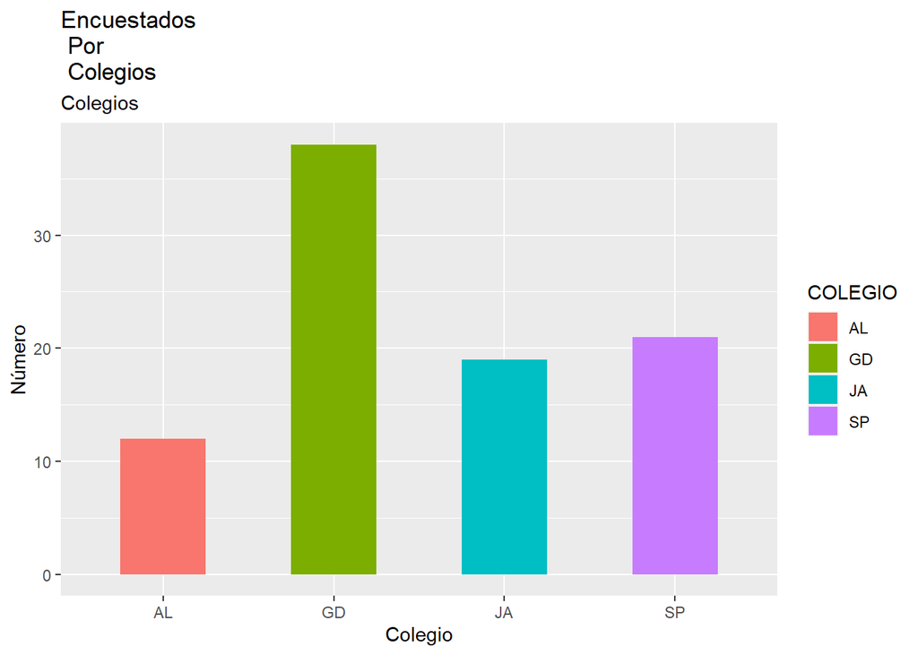

```r
ggplot(final,aes(x=COLEGIO,fill=COLEGIO))+
         geom_bar(width = 0.5)+
  xlab("Colegio") + ylab("Número")+
  ggtitle("Encuestados \n Por \n Colegios", subtitle = "Colegios")
```

La documentación sobre la función ggtitle indica que se pueden agregar subtítulos, poner el título en la parte inferior derecha (especial para derechos de autor), agregar una etiqueta o simplemente, bloquear poner algún título.

A continuación vamos agregarle derecho de autor al gráfico.

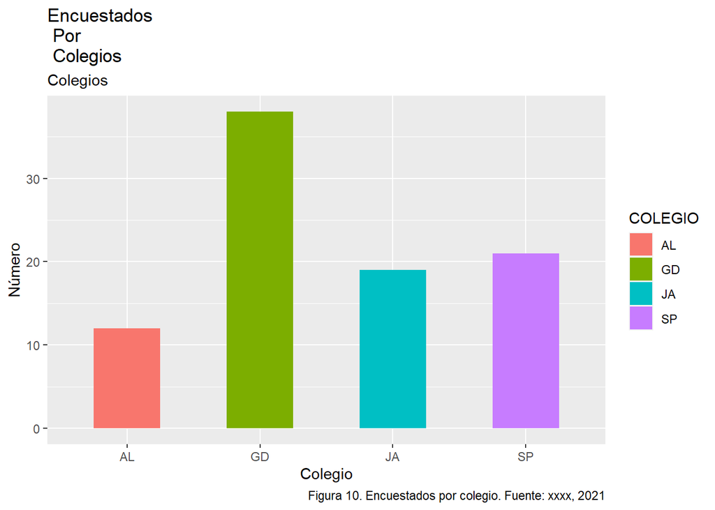

```r
ggplot(final,aes(x=COLEGIO,fill=COLEGIO))+
         geom_bar(width = 0.5)+
  xlab("Colegio") + ylab("Número")+ggtitle("Encuestados \n Por \n Colegios", subtitle = "Colegios")+
  labs(caption="Figura 10. Encuestados por colegio. Fuente: xxxx, 2021")
```

Siguiendo con la manipulación del estilo del gráfico, se le puede realizar una personilación y se le agrega al gráfico como una nueva capa. Primero vamos a definir la personalización del título.

```r
TemaTitulo = element_text(family = "Comic Sans MS",
                          face = "bold", #si se pone "bold" queda en negrilla
                          size = rel(2), #tamaño letra relativo a las demás
                          colour = "blue",
                          vjust = 0, #separar del gráfico
                          hjust = 0.5, #creo que centrar
                          angle = 0, #inclinación de la letra
                          lineheight=1, #separación entre líneas
                          debug = FALSE #como un fondo rectangular
                          )
```

Ahora le agregamos esa personalización de la siguiente manera:

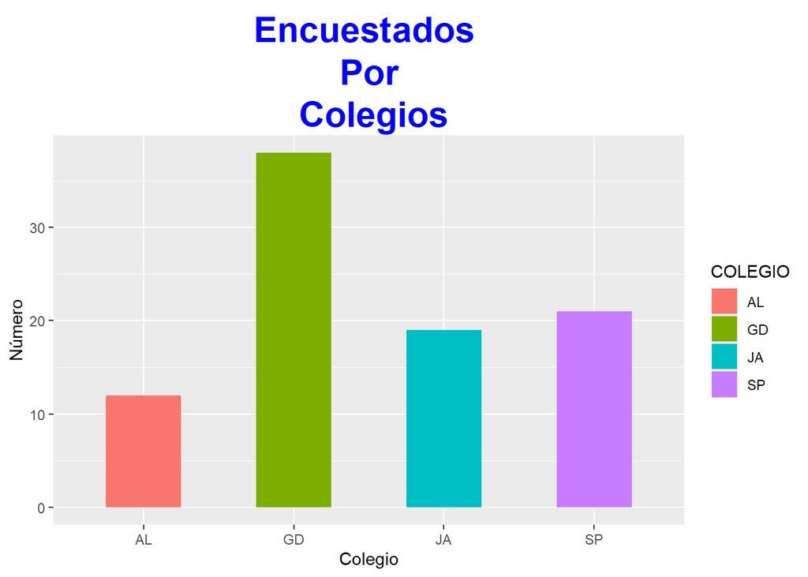

```r
ggplot(final,aes(x=COLEGIO,fill=COLEGIO))+
         geom_bar(width = 0.5)+
  xlab("Colegio") + ylab("Número")+
  ggtitle("Encuestados \n Por \n Colegios")+
  theme(plot.title = TemaTitulo)
```

Ahora vamos a reducir el tamaño de la letra:

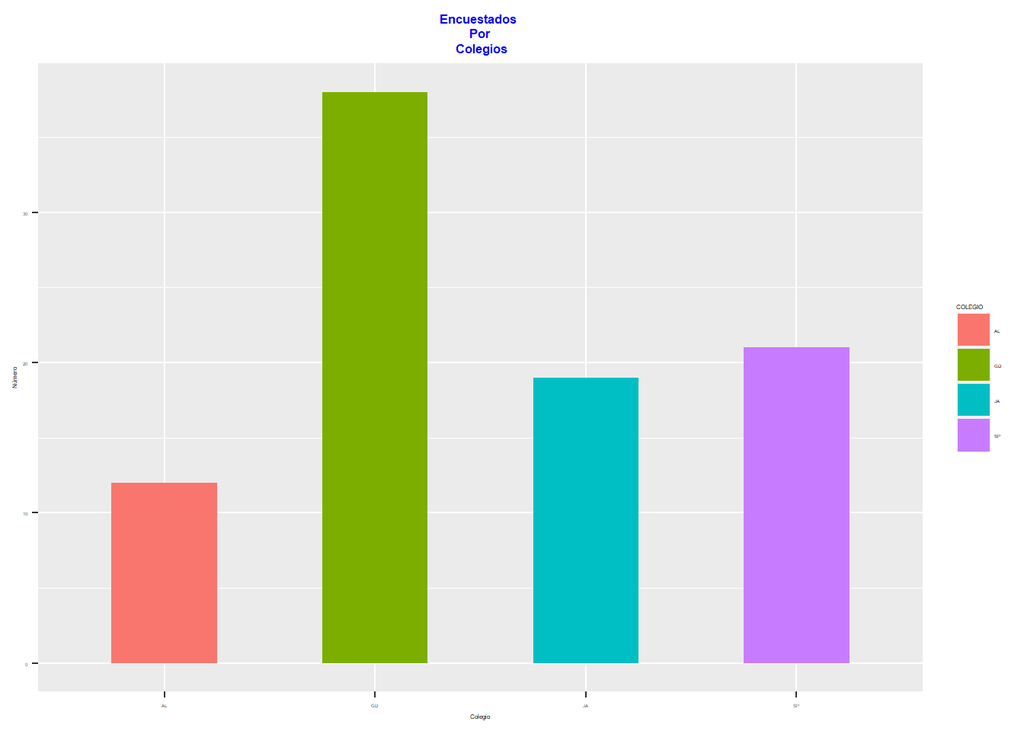

```r
ggplot(final,aes(x=COLEGIO,fill=COLEGIO))+
         geom_bar(width = 0.5)+
  xlab("Colegio") + ylab("Número")+
  ggtitle("Encuestados \n Por \n Colegios")+
  theme(plot.title = TemaTitulo)+theme (text = element_text(size=3))
```

Una vez manipulemos el título del gráfico, vamos a personalizar los títulos de los ejes.

```r
ejesTitulo = element_text(family = "Comic Sans MS",
                          face = "bold", #si se pone "bold" queda en negrilla
                          size = rel(1), #tamaño letra relativo a las demás
                          colour = "red",
                          vjust = 0, #separar del gráfico
                          hjust = 0.5, #creo que centrar
                          angle = 0, #inclinación de la letra
                          lineheight=1, #separación entre líneas
                          debug = FALSE) #como un fondo rectangular
```

Le agregamos la configuración al gráfico

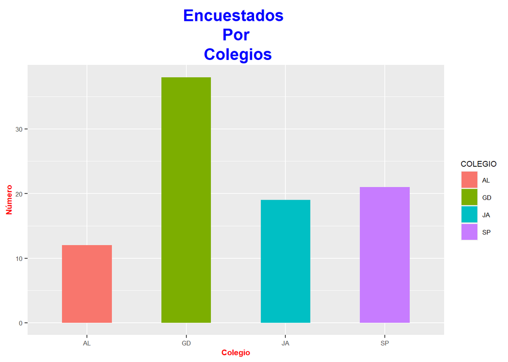

```r
ggplot(final,aes(x=COLEGIO,fill=COLEGIO))+
         geom_bar(width = 0.5)+
  xlab("Colegio") + ylab("Número")+
  ggtitle("Encuestados \n Por \n Colegios")+
  theme (text = element_text(size=8))+ #tamaño letra por defecto
  theme(plot.title = TemaTitulo)+
  theme(axis.title = ejesTitulo)
```

## AGREGAR TEXTO AL INTERIOR DEL GRÁFICO Y CANTIDADES

Utilizando la configuración básica (sin títulos en ejes y gráfico) vamos a incertar texto al interior del gráfico.

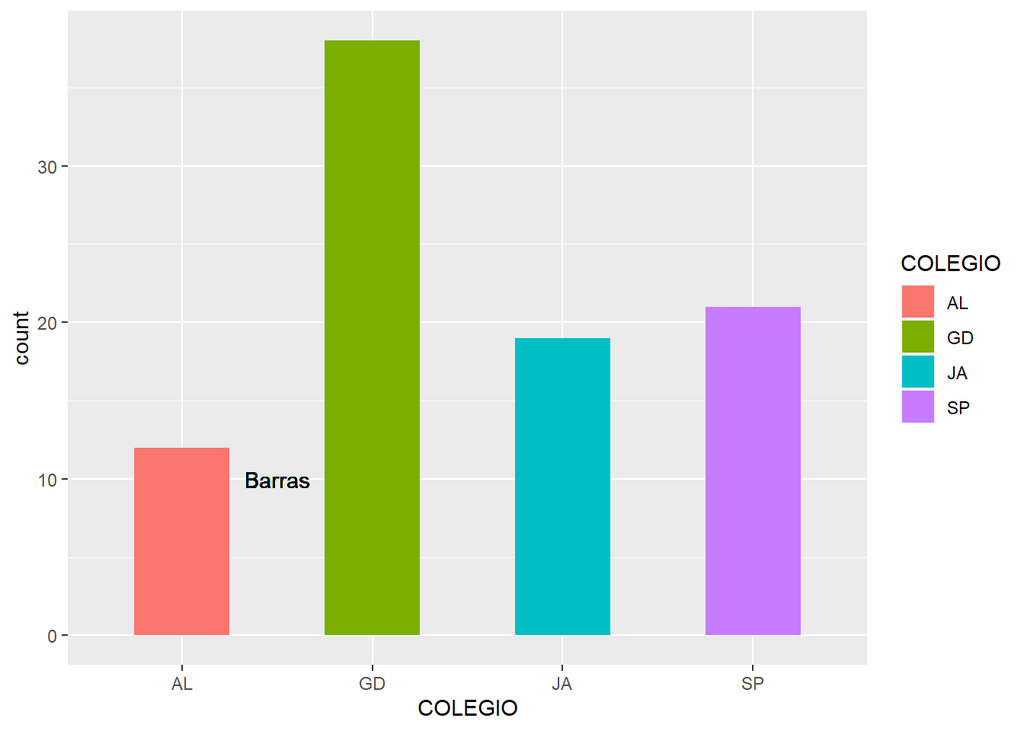

```r
ggplot(final,aes(x=COLEGIO,fill=COLEGIO))+
         geom_bar(width = 0.5)+
  geom_text(data = NULL,
            x=1.5, y=10,
            label="Barras")
```

Ahora agregar el valor cuantitativo y después un porcentaje. Se recomienda crear un nuevo dataframe basado en tablas de frecuencia y proporciones para este caso en particular.

```r
esc <- table(final$COLEGIO)
esc
```

```
##
## AL GD JA SP
## 12 38 19 21
```

```r
esc1 <- data.frame(esc)
names(esc1)=c("COLEGIO","CANTIDAD")
```

Es importante establacer stat=“identity” para que asuma la barra el valor e “y”.

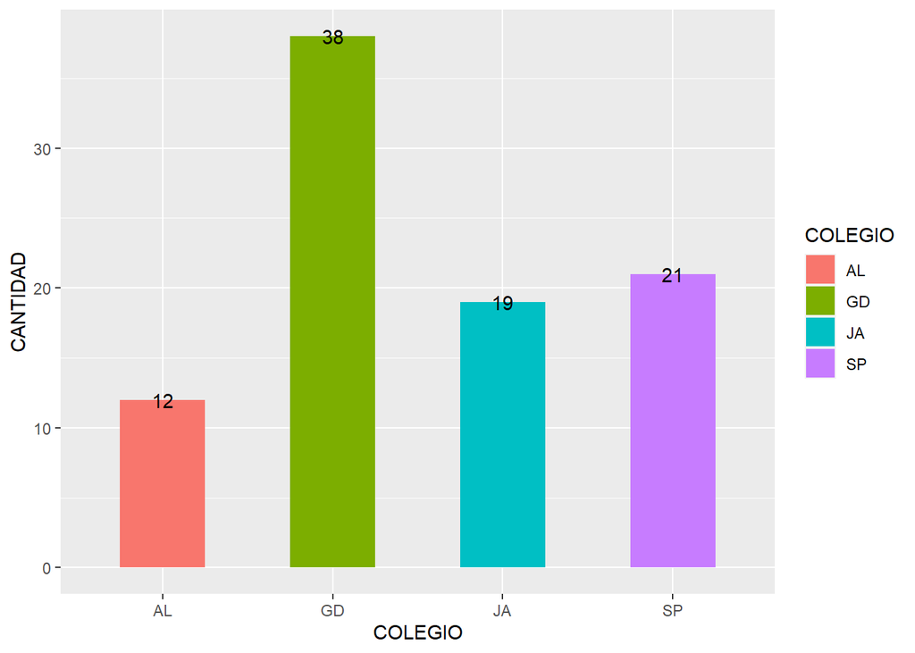

```r
ggplot(esc1,aes(x=COLEGIO,y=CANTIDAD,fill=COLEGIO))+
  geom_bar(stat = "identity", width = 0.5)+
  geom_text(aes(y = CANTIDAD, ymax = CANTIDAD, label = CANTIDAD))
```

Como se ve las cantidades no están en un lugar apropiado, por lo tanto deben moverse.

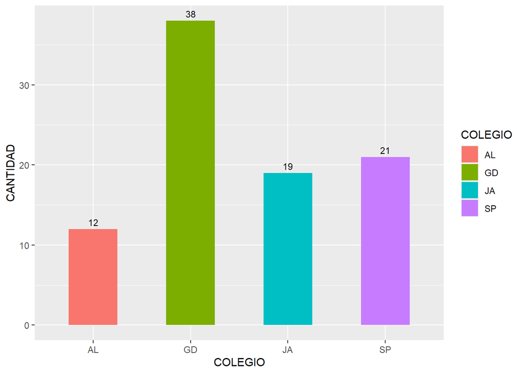

```r
ggplot(esc1,aes(x=COLEGIO,y=CANTIDAD,fill=COLEGIO))+
  geom_bar(stat = "identity", width = 0.5)+
  geom_text(aes(y = CANTIDAD, ymax = CANTIDAD, label = CANTIDAD),
            position = position_dodge(width = 1), # crea un espacio a ambos lados del gráfico
            size=3, vjust=-0.5, hjust=0.5 ,col="black")
```

Ahora se requiere que las barrar lleven porcentaje en vez cantidad. Se calcula la proporción y se adjunta al dataframe.

```r
prop.table(esc)
```

```
##
##        AL        GD        JA        SP
## 0.1333333 0.4222222 0.2111111 0.2333333
```

```r
Porcentaje <- paste(round(prop.table(esc)*100, 2),"%",sep="")

esc2 <- data.frame(esc1,Porcentaje)
esc2
```

```
##   COLEGIO CANTIDAD Porcentaje
## 1      AL       12     13.33%
## 2      GD       38     42.22%
## 3      JA       19     21.11%
## 4      SP       21     23.33%
```

Y se obtiene lo siguiente:

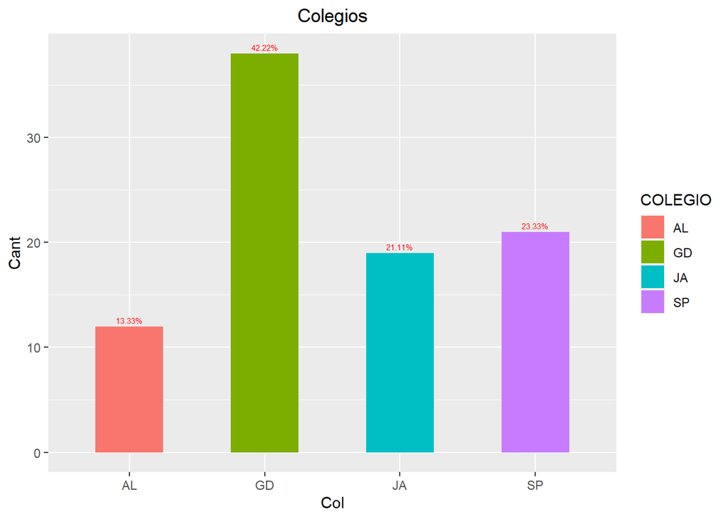

```r
ggplot(esc2,aes(x=COLEGIO,y=CANTIDAD,fill=COLEGIO))+
  geom_bar(stat = "identity", width = 0.5)+
  xlab("Col")+ylab("Cant")+
  ggtitle("Colegios")+
  theme(plot.title = element_text(hjust = 0.5))+
  geom_text(aes(label=Porcentaje),vjust=-0.5,col="red",size=2)
```

## GRÁFICOS DE BARRAS (2 FACTORES)

En esta sección se mostrarán las distintas formas de trabajar con gráficos de barras: apiladas, bloques, paneles y acomodadas por renglones. Nuevamente se hará uso de la data sobre el Endomarketing.

El primer paso es crear un nuevo dataframe con las dos variables tipo factor, otra variable que muestre la cantidad y la otra el porcentaje.

```r
frec1 <- table(final$SEXO)
Porcsex <- paste(round(prop.table(frec1)*100,2),"%",sep = "")
sex <- data.frame(frec1,Porcsex)
names(sex)=c("SEXO","CANTIDAD","PORCSEX")
sex
```

```
##     SEXO CANTIDAD PORCSEX
## 1 HOMBRE       23  25.56%
## 2  MUJER       67  74.44%
```